# Design de Jukeboxes - Baseline x Skip

## Usaremos a comparação entre baseline e a funcionalidade de skip para as musicas da jukebox.

Queremos comparar a diferença média entre a satisfacao usando a jukebox sem funcionalidades e a satisfacao usando a funcao de skip (pular musica) . Dito isso, o objetivo é investigar se é e quanto é plausível dizer, em média, que skip é preferível a função nenhuma, tendo em vista que, cancelar abruptamente uma musica pode diminuir a satisfacao de quem escolheu ela.

```r
library(tidyverse)
library(broom)
library(boot)

jukebox = read.csv("data/satisfacoes.csv") %>%
filter(scenario == "baseline" | scenario == "skip")
```

Primeiro vamos observar a faixa de valores que zero funcionalidade possui. Para isso, plotaremos o nível de satisfação por usuário.

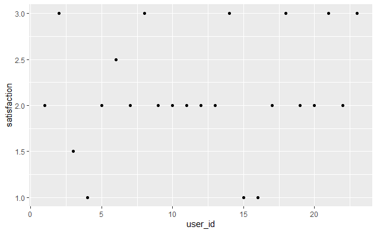

```r
jukebox %>%
filter(scenario == "baseline") %>%
ggplot(aes(user_id,satisfaction))+
geom_point()
```

```r
NA
NA
```

A maioria deles tem nota 2 e 3. Além disso, em uma escala de 1 a 5, nenhuma das avaliações supera nota 3.

E enquanto a faixa de valores para a funcao de skip?

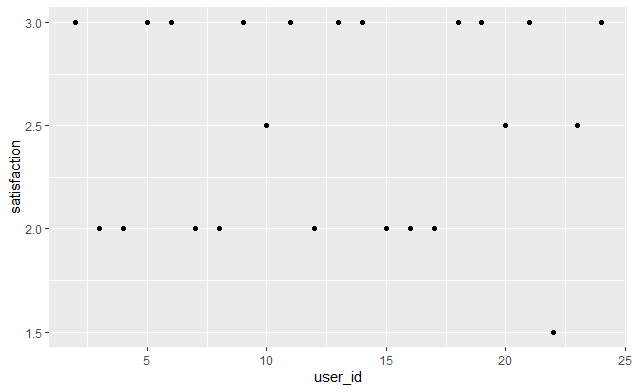

```r
jukebox %>%
filter(scenario == "skip") %>%
ggplot(aes(user_id,satisfaction))+
geom_point()
```

Nesse caso a faixa está centrada entre 2 e 3 com a maioria dos pontos em 2 e 3, ou seja, aparentemente as funcionalidades tem satisfações parecidas.

Queremos verificar agora, a partir dos resultados dessa amostra, para uma população qualquer, qual é uma provavél faixa da diferença média de satisfação entre esses dois mecanismos.

Para isso usaremos a tecnica de bootstrapping na amostra com o intuito de gerar novas amostras aleatórias, dessa forma, podemos inferir informações da população a partir do que temos.

| statistic | bias | std.error | conf.low | conf.high |
| --- | --- | --- | --- | --- |
| 0.3913043 | -0.0008621686 | 0.1235918 | 0.1346154 | 0.625 |

Como a diferença calculada foi skip - baseline(sem funcionalidades), quer dizer que: quanto mais positiva essa diferença, maior a preferência média pela funcão skip(pular faixa).

Com base nos cáculos, com 95% de confiança, é plausível afirmar que a diferença média entre a satisfação da funcionalidade skip e nenhuma funcionalidade varia entre 0.134 e 0.625. Ou seja, pode-se dizer que não é um absurdo alegar que a funcionalidade skip é preferível a nenhuma funcionalidade.

Tendo em vista que os níveis de satisfação variam de 1 a 5, podemos ver que a diferença média desses dois mecanismos é consideravelmente pequena, pois até o limite superior da faixa é menor que 1 ponto.